# houses1.R

jevon

2023-06-02

# Housing Prices Project (part 1)

In this file, you’ll visualize and model the relationship between square footage (`area`) and house prices (`price`). The main question: is that relationship best modeled as linear, log-linear, or log-log?

```r
library(tidyverse)
houses <- read_csv("https://raw.githubusercontent.com/cobriant/EC320Lab9/main/Housing.csv")
```

# 1. Linear Model (example: I’ll do this one for you)

First, visualize the relationship between `price` and `area` with a scatterplot. Then fit the model $price = \beta_0 + \beta_1 area + u$ and interpret the slope coefficient’s estimate and statistical significance.

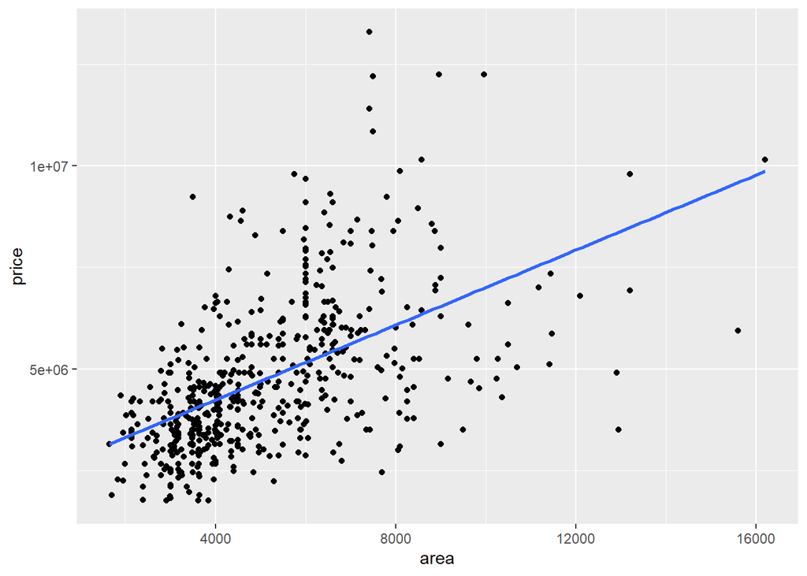

```r
houses %>%
  ggplot(aes(x = area, y = price)) +
  geom_point() +
  geom_smooth(method = lm, se = FALSE)
```

```r
houses %>%
  lm(price ~ area, data = .) %>%
  broom::tidy()
```

```
## # A tibble: 2 × 5
##   term        estimate std.error statistic  p.value
##   <chr>          <dbl>     <dbl>     <dbl>    <dbl>
## 1 (Intercept) 2387308.  174498.       13.7 8.06e-37
## 2 area            462.      31.2      14.8 7.39e-42
```

When area increases by one square foot, the house is expected to sell for $462 more. That estimate is significant at the 1% level.

# 2. Log-log Model

Visualize the relationship between `log(price)` and `log(area)` with a scatterplot. Then fit the model $log(price) = \beta_0 + \beta_1 log(area) + u$ and interpret the slope coefficient’s estimate and statistical significance.

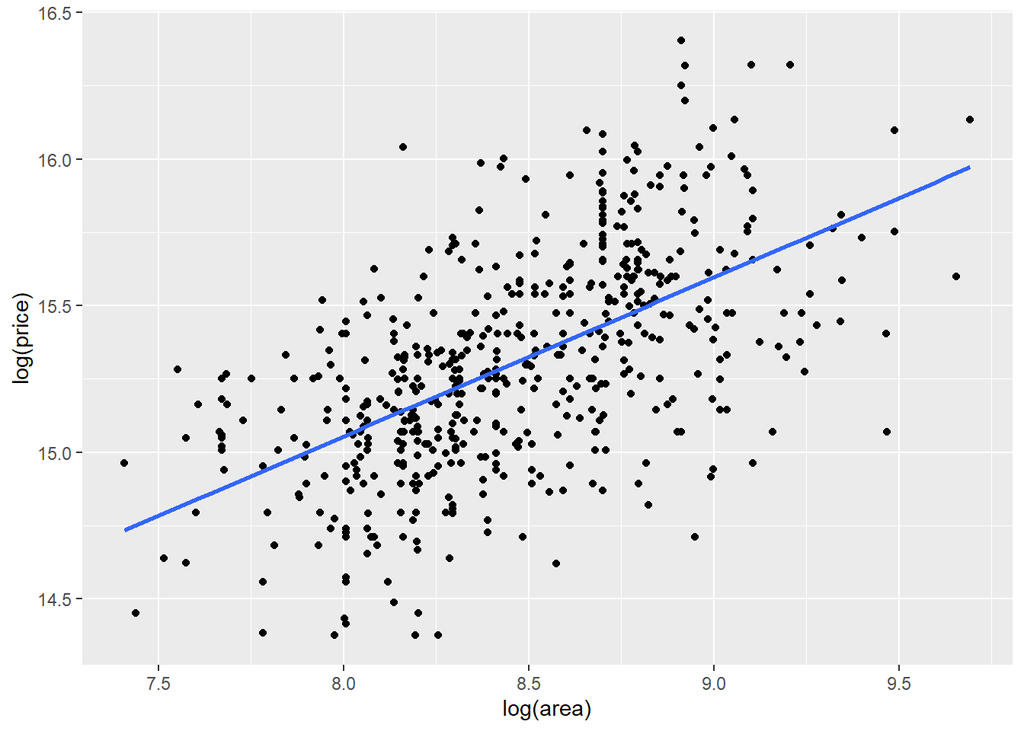

```r
houses %>%
  ggplot(aes(x = log(area), y = log(price))) +
  geom_point() +
  geom_smooth(method = lm, se = FALSE)
```

```r
houses %>%
  lm(log(price) ~ log(area), data = .) %>%
  broom::tidy()
```

```
## # A tibble: 2 × 5
##   term        estimate std.error statistic   p.value
##   <chr>          <dbl>     <dbl>     <dbl>     <dbl>
## 1 (Intercept)   10.7      0.277       38.7 2.74e-158
## 2 log(area)      0.542    0.0327      16.6 2.51e- 50
```

# 3. Log-linear Model

Visualize the relationship between `log(price)` and `area` with a scatterplot. Then fit the model $log(price) = \beta_0 + \beta_1 area + u$ and interpret the slope coefficient’s estimate and statistical significance.

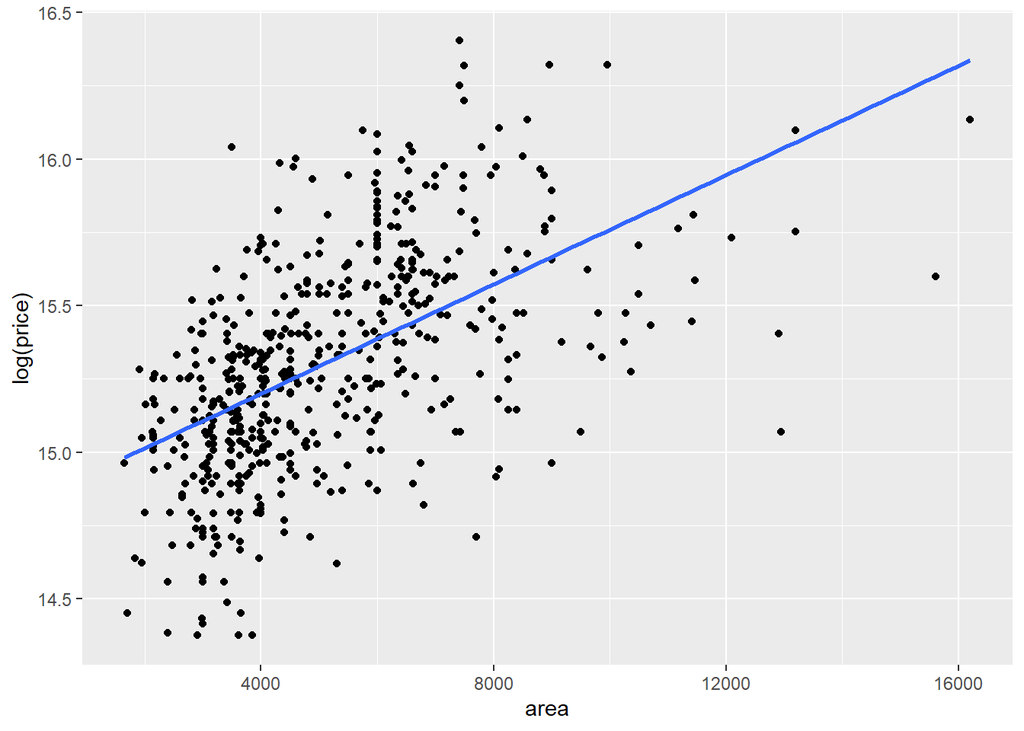

```r
houses %>%
  ggplot(aes(x = area, log(price))) +
  geom_point() +
  geom_smooth(method = lm, se = FALSE)
```

```r
houses %>%
  lm(log(price) ~ area, data = .) %>%
  broom::tidy()
```

```
## # A tibble: 2 × 5
##   term          estimate  std.error statistic  p.value
##   <chr>            <dbl>      <dbl>     <dbl>    <dbl>
## 1 (Intercept) 14.8       0.0345         429.  0
## 2 area         0.0000932 0.00000618      15.1 3.66e-43
```

# 4. When you review the scatterplots from the previous three questions, which

of these three models is the better fit? That is, which of these three transformations makes a linear model seem most plausible? the second one looks the best graphically so… log log method